# Mathematics behind Linear Regression and Logistic Regression

Author

Khiem Nguyen  
Lecturer in Multiscale Materials  
khiem.nguyen@glasgow.ac.uk

**Equations from main file `assignment_02.html`**

**General Dataset**
$$\mathcal{D} = \Big\{ \big( \mathbf{x}^{(1)}, y^{(1)} \big), \big( \mathbf{x}^{(2)}, y^{(2)} \big), \ldots, \big( \mathbf{x}^{(m)}, y^{(m)} \big) \Big\}
\tag{1}$$

**Gradient Descent Update Formla**
$$\Theta^{[t+1]} := \Theta^{[t]} - \alpha \nabla \mathcal{L}(\Theta^{[t]}),\quad \forall t= 0, 1, 2, \ldots
\tag{2}$$

# 1 Linear Regression with multiple features: Theory

In this section, we study:

- Description of a regresison problem
- Linear regression model
- Loss function for training the linear regression model
- Gradient of loss function

## 1.1 Problem description

We are given a dataset $\mathcal{D}$ with $m$ samples and each sample has $n$ input features $\mathbf{x}^{(i)} = (x_1^{(i)}, \ldots, x_n^{(i)}) \in \mathbb{R}^{n}$ and one output label $y \in \mathbb{R}^{n}$ – see Equation 1 again
$$\mathcal{D} = \Big\{ (\mathbf{x}^{(1)}, y^{(1)}), (\mathbf{x}^{(2)}, y^{(2)}), \ldots, (\mathbf{x}^{(m)}, y^{(m)}) \Big\}
\tag{3}$$

This dataset can be written in two matrices
$$\mathbf{X} = \begin{bmatrix}
x_1^{(1)} & x_{2}^{(1)} & \ldots & x_{n}^{(1)} \\[3pt]
x_1^{(2)} & x_{2}^{(2)} & \ldots & x_{n}^{(2)} \\[3pt]
\vdots & \vdots & \ddots & \vdots & \\[3pt]
x_1^{(m)} & x_{2}^{(m)} & \ldots & x_{n}^{(m)}
\end{bmatrix}, \qquad
\mathbf{y} = \begin{bmatrix} y_{\phantom{1}}^{(1)} \\[3pt]
y_{\phantom{1}}^{(2)} \\[3pt]
\vdots \\[3pt]
y_{\phantom{1}}^{(m)}
\end{bmatrix}
\tag{4}$$

Our task is to build a model, which is actually just a function or a mapping, to predict a new output $\widehat{y}$ given a new sample (data point) $\mathbf{x}$. That is we need to construct the function $f = f(\mathbf{x})$ so that it fits the data very well. If the model can be visualized, we expect the graph $y = f(\mathbf{x})$ should fit the data points in the high-dimensional space $\mathbf{R}^{n + 1}$ very well. Now, we go through three steps mentioned in section “Build and Train ML models”

## 1.2 Linear regression model

The linear regression model is defined by a simple linear relationship between input $\mathbf{x}$ and output $y$:
$$\widehat{y} = f_{\mathbf{w}, b}(\mathbf{x})= \mathbf{w}\cdot \mathbf{x} + b.$$
The parameters $\mathbf{w} = (w_1, \ldots, w_n)$ are called **weights** and the parameter $b$ is called **bias**. This linear regression model is fully determined by the **learnable parameters** $\mathbf{w}=(w_1, \ldots, w_n)$ and $b$. **Our objective** is to seek these *learnable parameters* $w_1, \ldots, w_n$ and $b$.

## 1.3 Loss function

To measure how well the model is, we use the **Mean Square Error** (MSE) loss function:
$$\begin{aligned}
\mathcal{L}(\mathbf{w}, b) &= \frac{1}{m} \sum\limits_{i=1}^{m}(\widehat{y} \big(\mathbf{x}^{(i)}) - y^{(i)} \big)^2 = \frac{1}{m} \sum\limits_{i=1}^{m} \big(f_{\mathbf{w},b}(\mathbf{x}^{(i)}) - y^{(i)} \big)^2 \\
&= \frac{1}{m} \sum\limits_{i=1}^{m} \big(\mathbf{w}\cdot \mathbf{x}^{(i)} + b - y^{(i)} \big)^2
\end{aligned}
\tag{5}$$

Note that we don’t use $2m$ in the denominator as in the Assignment 01. This is just to prove that the minimium point is exactly the same, only the minimum value is scaled by a factor $1/2$. For this reason, the gradient $\nabla \mathcal{L}$ will be also scaled (see below).

It is immediately clear that the loss function $\mathcal{L}$ defined as above is just a function of $\mathbf{w}$ and $b$ because the values $\mathbf{x}^{(i)}$ and $y^{(i)}$ for all $i = 1, \ldots, m$ are given in the dataset $\mathcal{D}$ (e.g., in the `.csv` file).

We recall here “training the model” means “looking for $\mathbf{w}$ and $b$” and the way to do this is to implement the gradient descent method given by the iteration formula Equation 2. In the current case, the variable $\Theta$ corresponds to the model parameters $\mathbf{w}$ and $b$. To implement the update rule given by Equation 2, we need to compute the gradient $\nabla\mathcal{L}$ which refers to derivatives of $\mathcal{L}$ with respect to $w_1, w_2, \ldots, w_n$ and to $b$:
$$\nabla \mathcal{L} = \bigg(\frac{\partial \mathcal{L}}{\partial w_1}, \cdots, \frac{\partial \mathcal{L}}{\partial w_n}, \frac{\partial \mathcal{L}}{\partial b} \bigg)$$

Therefore, we need to compute the gradient of the loss function $\nabla\mathcal{L}$ to perform the gradient descent iteration algorithm.

## 1.4 Gradient of loss function

The gradient of $\mathcal{L}$ given by Equation 5 is computed as follows[^1] – If you are interested in the derivation, please refer `derivation.html`.
$$\begin{aligned}
\frac{\partial \mathcal{L}}{\partial w_1} &= \frac{2}{m} \sum\limits_{i=1}^{m} \big(\widehat{y}(\mathbf{x}^{(i)}) - y^{(i)} \big) x_{1}^{(i)} \\[3pt]
& \text{so on} \\[3pt]
\frac{\partial \mathcal{L}}{\partial w_n} &= \frac{2}{m} \sum\limits_{i=1}^{m} \big(\widehat{y}(\mathbf{x}^{(i)}) - y^{(i)} \big) x_{n}^{(i)} \\[3pt]
\frac{\partial \mathcal{L}}{\partial b} &= \frac{2}{m} \sum\limits_{i=1}^{m} \big(\widehat{y}(\mathbf{x}^{(i)}) - y^{(i)} \big) \cdot 1 \\[3pt]
\end{aligned}$$
Note that since we have $m$ instead of $2m$ in the denominator of Equation 5, the gradient is also scaled, and thus we see number $2$ in the nominator of $\frac{2}{m}$ as compared to $\frac{1}{m}$ in the Assignment 01. By plugging these equations in Equation 2, we obtain the following update rule
$$\begin{aligned}
w_1^{[t+1]} &:= w_{1}^{[t]} - \frac{2}{m} \sum\limits_{i=1}^{m} \big[\big(\mathbf{w}^{[t]} \cdot \mathbf{x}^{(i)} + b^{[t]}\big) - y^{(i)} \big] x_{1}^{(i)} \\[3pt]
& \text{so on} \\[3pt]
w_n^{[t+1]} &:= w_{n}^{[t]} - \frac{2}{m} \sum\limits_{i=1}^{m} \big[\big(\mathbf{w}^{[t]} \cdot \mathbf{x}^{(i)} + b^{[t]}\big) - y^{(i)} \big] x_{n}^{(i)} \\[3pt]
b^{[t+1]} &:= b^{[t]} - \frac{2}{m} \sum\limits_{i=1}^{m} \big[\big(\mathbf{w}^{[t]} \cdot \mathbf{x}^{(i)} + b^{[t]}\big) - y^{(i)} \big] \cdot 1\\[3pt]
\end{aligned}$$

## 1.5 Numerical Example

**The Black Box Trap** In modern engineering and physics, it is easy to feed parameters into a simulation or a Python script and get a result. However, this normally leads to the feeling that “we understand it” while in reality “we don’t quite really understand it.”

**Tip**

In **MIT** or **CalTech** you will frequently hear professors and Teaching Assitants reiterate some version of “If you cannot solve it for $n = 2$, you don’t understand the general case.”

For this reason, let us go through all the theoretical steps above using a simple $2$-dimensional example with $4$ samples. Note that with only $3$ points, we can always build a plane that go through all $3$ points. Thus, we chose $4$ points.

**Dataset**

For reproducibility purpose, we design the dataset by using the exact/reference linear regression model:

$$f(x_1, x_2) = \frac{1}{2} x_1 - \frac{1}{2} x_2 + \frac{3}{2}
\tag{6}$$

The dataset is given by the following table

| $x_1$ | $x_2$ | $y$ |
| --- | --- | --- |
| $0$ | $0$ | $3/2$ |
| $1$ | $0$ | $2$ |
| $0$ | $1$ | $1$ |
| $1$ | $1$ | $v$ |

We keep the label value of the last data point general, denoted by $v$. We shall see that by adjusting $v$, the loss function will also change and the minimum point is not always equal to $0$.

### 1.5.1 Hand-written calculation

**Linear Regression Model**

In this example, we have $2$ features. The linear regression model for $2$ input features reads
$$\widehat{y} = f_{\mathbf{w}, b}(x_1, x_2) = w_1 x_1 + w_2 x_2 + b.$$

**Loss Function**

We reiterate the formula for the loss function
$$\begin{aligned}
\mathcal{L}(w_1, w_2, b) &= \frac{1}{4} \sum_{i=1}^{4} \big(\hat{y}^{(i)} - y^{(i)} \big)^2 = \frac{1}{4}\sum\limits_{i=1}^{4} \big[ e^{(i)} \big]^2 \\[3pt]
&= \frac{1}{4} \sum\limits_{i=1}^{4}\Big( w_1 x_1^{(i)} + w_2 x_2^{(i)} + b - y^{(i)} \Big)^2
\end{aligned}
\tag{7}$$

where the error term $e^{(i)}$ is defined by
$$\begin{aligned}
e^{(i)} &= \widehat{y}^{(i)} - y^{(i)} = f_{\mathbf{w}, b}(\mathbf{x}^{(i)}) - y^{(i)} \\[3pt]
&= w_1 x_1^{(i)} + w_2 x_2^{(i)} + b - y^{(i)}.
\end{aligned}$$

For the dataset with $m=4$ samples, we calculate the individual squared errors by direct substitution:
$$\begin{aligned}
\text{For } (0, 0, 3/2) &: e^{(1)} = (b - 3/2) \\[6pt]
\text{For } (1, 0, 2) &: e^{(2)} = (w_1 + b - 2) \\[6pt]
\text{For } (0, 1, 1) &: e^{(3)} = (w_2 + b - 1) \\[6pt]
\text{For } (1, 1, v) &: e^{(4)} = (w_1 + w_2 + b - v)
\end{aligned}$$

Substituting these expressions for $e^{(i)}$ into Equation 7, we arrive at the total loss function
$$\mathcal{L}(w_1, w_2, b) = \frac{1}{4} \bigg[ \left(b - \frac{3}{2}\right)^2 +
(w_1 + b - 2)^2 + (w_2 + b - 1)^2 + (w_1 + w_2 + b - v)^2 \bigg]$$

**Note** It is clear that no matter how complicated the dataset is, the loss function for linear regression models is a quadratic function with respect to the model parameters. In this case, $\mathcal{L}$ is a quadratic function of $(w_1, w_2, b)$. For this reason, there exists one and only one minimal point $\mathcal{L}$, which is computed by solving the equation $\nabla \mathcal{L} = 0$.

**Gradient of the Loss Function**

The mimization of $\mathcal{L}$ can be obtained by solving the equation $\nabla \mathcal{L} = 0$, namely the equations retrieved by setting the partial derivative of $\mathcal{L}$ with respect to all the variables to $0$. In this case, it simply reads
$$\nabla\mathcal{L} = 0\quad\Leftrightarrow \quad \left\{\begin{aligned}
\frac{\partial \mathcal{L}}{\partial w_1} &= 0, \\[3pt]
\frac{\partial \mathcal{L}}{\partial w_1} &= 0, \\[3pt]
\frac{\partial \mathcal{L}}{\partial b} &= 0\end{aligned} \right.
\tag{8}$$

We can easily derive
$$\frac{\partial \mathcal{L}}{\partial w_1} = \frac{1}{2} \left[ (w_1 + b - 2) + (w_1 + w_2 + b - v) \right], \qquad \frac{\partial \mathcal{L}}{\partial w_2} = \frac{1}{2} \left[ (w_2 + b - 1) + (w_1 + w_2 + b - v) \right], \qquad \frac{\partial \mathcal{L}}{\partial b} = \frac{1}{2} \left[ (b - 1.5) + (w_1 + b - 2) + (w_2 + b - 1) + (w_1 + w_2 + b - v) \right]$$

Then, we obtain a system of $3$ equations for $3$ **learnable parameters** $w_1, w_2, b$. The three equations given by the optimality condition Equation 8 have one single solution:

$$\begin{aligned}
w_1 &= \frac{2v - 1}{4} \\
w_2 &= \frac{2v - 5}{4} \\
b &= \frac{15 - 2v}{8}
\end{aligned}
\tag{9}$$

**Discussion on the loss function**

By substituting Equation 9 into the loss function Equation 7, we obtain the minimum of the loss function – note that this minimum value still depends on $v$ because we allow the forth data points to move freely in the $y$-axis with value $v$:

Substituting the optimal parameters back into the error terms (without being squared here):
$$\begin{aligned}
e^{(1)} &= \left(\frac{2v - 1}{4}\right) \cdot 0 + \left(\frac{2v - 5}{4}\right) \cdot 0 + \left( \frac{15 - 2v}{8}\right) - \frac{3}{2} = \frac{3 - 2v}{8} \\
e^{(2)} &= \left(\frac{2v - 1}{4}\right) \cdot 1 + \left(\frac{2v - 5}{4}\right) \cdot 0 + \left(\frac{15 - 2v}{8}\right) - 2 = \frac{2v - 3}{8} \\
e^{(3)} &= \left(\frac{2v - 1}{4}\right) \cdot 0 + \left(\frac{2v - 5}{4}\right) \cdot 1 + \left(\frac{15 - 2v}{8}\right) - 1 = \frac{2v - 3}{8} \\
e^{(4)} &= \left(\frac{2v - 1}{4}\right) \cdot 1 + \left(\frac{2v - 5}{4}\right) \cdot 1 + \left(\frac{15 - 2v}{8}\right) - v = \frac{3 - 2v}{8}
\end{aligned}$$

The loss function evaluates to
$$\mathcal{L}_{\text{min}} = \frac{1}{4}\sum\limits_{i=1}^{4} \big[e^{(i)}\big]^2 = \frac{(2v - 3)^2}{64}$$

**Note**

**The minimum of a loss function does not need to be zero**

As we can see the minimal loss function $\mathcal{L}_\text{min}$ can be non-zero depending on $v$. The next legitimate question is that what it implies when $\mathcal{L}_\text{min} = 0$. Let us think of this scenario.

The loss function measures how well our prediction model makes prediction on the seen/given data. The zero loss function implies that the model has made perfect prediction on the seen/given dataset because all the error terms $e^{(i)}$ must be equal to zero for this to occur. As a consequence, all the data points sit perfectly on the graph of the function
$$(G): \quad y = f_{\mathbf{w}, b}(\mathbf{x}) = w_1 x_1 + w_2 x_2 + b.$$

For a dataset of $3$ data points, we can always construct a plane going through all the data points regardless of the actual values of the data points. This is no longer the case for $4$ data points. When $v = 3/2$, the minimum of loss function is equal to zero, $\mathcal{L}_{\text{min}} = 0$. In this case, the 4th data point is given by $(1, 1, 3/2)$, which sits perfectly on the graph – see the reference model Equation 6

$$y = \widehat{f}(x_1, x_2) = \frac{1}{2}x_1 - \frac{1}{2}x_2 + \frac{3}{2}$$

because $y^{(4)} = \widehat{f}(x_1^{(4)}, x_2^{(4)})$:
$$\frac{3}{2} = \frac{1}{2} \cdot 1 - \frac{1}{2} \cdot 1 + \frac{3}{2}$$

### 1.5.2 Python implementation using symbolic computation

Instead of computing the loss function by hand, I take this opportunity to introduce you to a useful library in Python: [SymPy](https://www.sympy.org/). To this end, please just follow the code snippet. The code is quite easy to understand.

First of all, you need to activate the conda environment or the virtual environment and then install `sympy` by using one of the following towo command lines:

```bash
conda install sympy
```

```bash
pip install sympy
```

**Compute loss function**

As the starting point, we setup the dataset, define the linear regression model and compute the loss function with the help of symbolic calculation by `sympy` library.

```python
import sympy as sp

# Define symbols
w1, w2, b, v = sp.symbols('w1 w2 b v')

# Define the dataset (x1, x2, y)
data = [(0, 0, 3/2), (1, 0, 2), (0, 1, 1), (1, 1, v)]

def model(x1_val, x2_val):
    return w1 * x1_val + w2 * x2_val + b

# Compute the sum of squared errors
squared_errors = []
for x1_val, x2_val, y_val in data:
    pred = model(x1_val, x2_val)    # compute prediction using the model.
    squared_err = (pred - y_val)**2
    squared_errors.append(squared_err)

n_samples = len(data)
loss_function = 1 / (n_samples) * sum(squared_errors)

# Display results
def prettify(text: str, n_dashes=30, char="="):
    long_dash = n_dashes*char
    print("\n" + long_dash + "\n" + text + "\n" + long_dash)

prettify("Symbolic Loss Function")
sp.pprint(loss_function)
```

```
==============================
Symbolic Loss Function
==============================
              2                    2                    2                      ↪
0.25⋅(b - 1.5)  + 0.25⋅(b + w₁ - 2)  + 0.25⋅(b + w₂ - 1)  + 0.25⋅(b - v + w₁ + ↪

↪     2
↪  w₂)
```

**Compute gradient of loss function and optimal parameters of the linear regression model**

Next, we solve the equation $\nabla \mathcal{L} = 0$ for the “learnable parameters”, namely the model parameters $(w_1, w_2, b)$. The results are printed for comparison with hand calculation above.

**Tip**

In fact, I used the results obtained by Python to write down the hand-written computation.

```python
# Compute the gradients
grad_w1 = sp.diff(loss_function, w1)
grad_w2 = sp.diff(loss_function, w2)
grad_b = sp.diff(loss_function, b)

grad = [("dL/dw1", grad_w1), ("dL/dw2", grad_w2), ("dL/db", grad_b)]
prettify(f"Gradient of the Loss Function")
for deriv, expr in grad:
    print(f"{deriv} = {expr}")

# Solve the system gradient-of-loss = 0
solution = sp.solve([grad_w1, grad_w2, grad_b], (w1, w2, b))

prettify(f"Optimized model parameters")
for param, expr in solution.items():
    print(f"{param} = {expr}")
```

```
==============================
Gradient of the Loss Function
==============================
dL/dw1 = 1.0*b - 0.5*v + 1.0*w1 + 0.5*w2 - 1.0
dL/dw2 = 1.0*b - 0.5*v + 0.5*w1 + 1.0*w2 - 0.5
dL/db = 2.0*b - 0.5*v + 1.0*w1 + 1.0*w2 - 2.25

==============================
Optimized model parameters
==============================
b = 1.875 - 0.25*v
w1 = 0.5*v - 0.25
w2 = 0.5*v - 1.25
```

**Compute minimum of loss function**

By direct substitution of the solution obtained above into the loss function `loss`, we can compute the minimum of the loss function

```python
# Substitute the solution for w1, w2, b into loss function
min_loss = loss_function.subs(solution)
min_loss_simplified = sp.simplify(min_loss)

prettify(f"Min of loss function")
print(f"L_min = {min_loss_simplified}")

# Solve L_min = 0 for v
vhat = sp.solve(min_loss_simplified, v)[0]
print(f"v (for L_min = 0): {vhat:.3f}")
```

```
==============================
Min of loss function
==============================
L_min = 1.0*(0.25*v - 0.375)**2
v (for L_min = 0): 1.500
```

**Visualization**

Let us visualize the results.

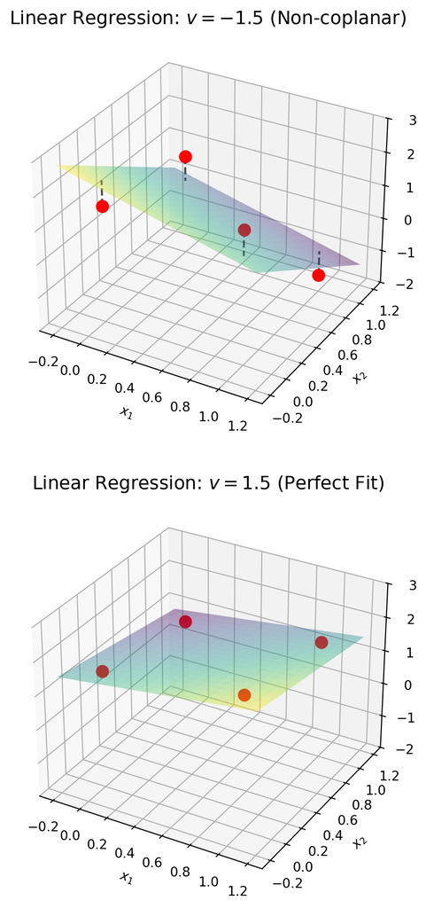

```python
import numpy as np
import matplotlib.pyplot as plt
from mpl_toolkits.mplot3d import Axes3D

def plot_regression_3d(v_val, ax, title):
    # Data points
    x1_data = np.array([0, 1, 0, 1])
    x2_data = np.array([0, 0, 1, 1])
    y_data  = np.array([1.5, 2, 1, v_val])

    # Optimal parameters (derived from grad L = 0)
    w1 = (2 * v_val - 1) / 4
    w2 = (2 * v_val - 5) / 4
    b  = (15 - 2 * v_val) / 8

    # 3. Create grid for the plane
    x1_range = np.linspace(-0.2, 1.2, 20)
    x2_range = np.linspace(-0.2, 1.2, 20)
    X1, X2 = np.meshgrid(x1_range, x2_range)
    Y_plane = w1 * X1 + w2 * X2 + b

    surf = ax.plot_surface(X1, X2, Y_plane, alpha=0.4, cmap='viridis', edgecolor='none')

    ax.scatter(x1_data, x2_data, y_data, color='red', s=80, depthshade=False, label='Data')

    # Plot residuals (vertical error lines)
    for i in range(len(x1_data)):
        pred = w1 * x1_data[i] + w2 * x2_data[i] + b
        ax.plot([x1_data[i], x1_data[i]], [x2_data[i], x2_data[i]], [y_data[i], pred],
                color='black', linestyle='--', alpha=0.7)

    # Formatting
    ax.set_title(title, fontsize=14)
    ax.set_xlabel('$x_1$')
    ax.set_ylabel('$x_2$')
    ax.set_zlabel('$y$')
    ax.set_zlim(-2, 3) # Keep scale consistent for comparison

# Create the figure with two subplots
fig = plt.figure(figsize=(4.5, 10))

# Figure 1: v = -1.5 (High Loss)
ax1 = fig.add_subplot(211, projection='3d')
plot_regression_3d(-1.5, ax1, "Linear Regression: $v = -1.5$ (Non-coplanar)")

# Figure 2: v = 1.5 (Zero Loss)
ax2 = fig.add_subplot(212, projection='3d')
plot_regression_3d(1.5, ax2, "Linear Regression: $v = 1.5$ (Perfect Fit)")

plt.tight_layout()
plt.show()
```

# 2 Logistic Regression with multiple features

In this section, we study:

- Description of a classification problem
- Logistic regression model
- Loss function for training the logistic regression model
- Gradient of loss function

## 2.1 Problem description

For this reason, the dataset notation Equation 3 and the matrix-presentation of this dataset Equation 4 should be the same except that the label $y^{(i)}$ for all the samples can take only one value in the finite set $\{0, \ldots, K-1\}$ for the $K$-category classification problem.

## Footnotes

[^1]: You can try to carry out the derivation. It is surprisingly easy to be honest. Clever students like you will definitely do this 😏😏